# Multinomial Logistic Regression DrPH Sem 2

Author

Dr Hazlienor Mohd Hatta

Published

July 1, 2024

# Multinomial Logistic Regression

## Research Question

When high school students choose the program (general, vocational, and academic programs), how do their gender, math and science scores and their social economic status (SES) affect their decision?

### Justification for multinomial logistic regression

The researcher would like the study the influence of several factors on the outcome variable. The outcome is polychotomous categorical variable with more than two levels and has no natural ordering. Multinomial logistic regression allows for modeling the probabilities of the outcome categories relative to a chosen reference category.

### Alternative

- Multinomial probit regression, similar to multinomial logistic regression with independent normal error terms.
- Multiple-group discriminant function analysis. A multivariate method for multinomial outcome variables
- Multiple logistic regression analyses, one for each pair of outcomes: One problem with this approach is that each analysis is potentially run on a different sample. The other problem is that without constraining the logistic models, we can end up with the probability of choosing all possible outcome categories greater than 1.
- Collapsing number of categories to two and then doing a logistic regression: This approach suffers from loss of information and changes the original research questions to very different ones.
- Ordinal logistic regression: If the outcome variable is truly ordered and if it also satisfies the assumption of proportional odds, then switching to ordinal logistic regression will make the model more parsimonious.
- Alternative-specific multinomial probit regression, which allows different error structures therefore allows to relax the IIA assumption. This requires that the data structure be choice-specific.
- Nested logit model, another way to relax the IIA assumption, also requires the data structure be choice-specific.

## Prepare environment

```r
library(haven) # read data
library(tidyverse) # data manipulation
```

```
✖ purrr::%||%()   masks base::%||%()
```

```r
library(gtsummary) # data tabulation
library(VGAM) # multinomial regression
library(broom)
```

## Dataset

The data set(hsbdemo.sav) contains variables on 200 students. The outcome variable is prog, program type (1=general, 2=academic, and 3=vocational). The predictor variables are ses, social economic status (1=low, 2=middle, and 3=high), math, mathematics score, and science, science score: both are continuous variables.

### Load Data

```r
hsbdemo <- read_dta("https://stats.idre.ucla.edu/stat/data/hsbdemo.dta")
```

### Data exploration

```r
str(hsbdemo)
```

```
tibble [200 × 13] (S3: tbl_df/tbl/data.frame)
 $ id     : num [1:200] 45 108 15 67 153 51 164 133 2 53 ...
  ..- attr(*, "format.stata")= chr "%9.0g"
 $ female : dbl+lbl [1:200] 1, 0, 0, 0, 0, 1, 0, 0, 1, 0, 1, 0, 0, 1, 1, 0, 1, 1, ...
   ..@ format.stata: chr "%9.0g"
   ..@ labels      : Named num [1:2] 0 1
   .. ..- attr(*, "names")= chr [1:2] "male" "female"
 $ ses    : dbl+lbl [1:200] 1, 2, 3, 1, 2, 3, 2, 2, 2, 2, 1, 3, 1, 2, 1, 1, 1, 2, ...
   ..@ format.stata: chr "%9.0g"
   ..@ labels      : Named num [1:3] 1 2 3
   .. ..- attr(*, "names")= chr [1:3] "low" "middle" "high"
 $ schtyp : dbl+lbl [1:200] 1, 1, 1, 1, 1, 1, 1, 1, 1, 1, 1, 1, 1, 1, 1, 1, 1, 1, ...
   ..@ label       : chr "type of school"
   ..@ format.stata: chr "%9.0g"
   ..@ labels      : Named num [1:2] 1 2
   .. ..- attr(*, "names")= chr [1:2] "public" "private"
 $ prog   : dbl+lbl [1:200] 3, 1, 3, 3, 3, 1, 3, 3, 3, 3, 3, 2, 3, 3, 3, 1, 1, 3, ...
   ..@ label       : chr "type of program"
   ..@ format.stata: chr "%9.0g"
   ..@ labels      : Named num [1:3] 1 2 3
   .. ..- attr(*, "names")= chr [1:3] "general" "academic" "vocation"
 $ read   : num [1:200] 34 34 39 37 39 42 31 50 39 34 ...
  ..- attr(*, "label")= chr "reading score"
  ..- attr(*, "format.stata")= chr "%9.0g"
 $ write  : num [1:200] 35 33 39 37 31 36 36 31 41 37 ...
  ..- attr(*, "label")= chr "writing score"
  ..- attr(*, "format.stata")= chr "%9.0g"
 $ math   : num [1:200] 41 41 44 42 40 42 46 40 33 46 ...
  ..- attr(*, "label")= chr "math score"
  ..- attr(*, "format.stata")= chr "%9.0g"
 $ science: num [1:200] 29 36 26 33 39 31 39 34 42 39 ...
  ..- attr(*, "label")= chr "science score"
  ..- attr(*, "format.stata")= chr "%9.0g"
 $ socst  : num [1:200] 26 36 42 32 51 39 46 31 41 31 ...
  ..- attr(*, "label")= chr "social studies score"
  ..- attr(*, "format.stata")= chr "%9.0g"
 $ honors : dbl+lbl [1:200] 0, 0, 0, 0, 0, 0, 0, 0, 0, 0, 0, 0, 0, 0, 0, 0, 0, 0, ...
   ..@ label       : chr "honors english"
   ..@ format.stata: chr "%19.0g"
   ..@ labels      : Named num [1:2] 0 1
   .. ..- attr(*, "names")= chr [1:2] "not enrolled" "enrolled"
 $ awards : num [1:200] 0 0 0 0 0 0 0 0 0 0 ...
  ..- attr(*, "format.stata")= chr "%9.0g"
 $ cid    : num [1:200] 1 1 1 1 1 1 1 1 1 1 ...
  ..- attr(*, "format.stata")= chr "%8.0g"
 - attr(*, "label")= chr "highschool and beyond (200 cases)"
```

```r
summary(hsbdemo)
```

```
       id             female           ses            schtyp
 Min.   :  1.00   Min.   :0.000   Min.   :1.000   Min.   :1.00
 1st Qu.: 50.75   1st Qu.:0.000   1st Qu.:2.000   1st Qu.:1.00
 Median :100.50   Median :1.000   Median :2.000   Median :1.00
 Mean   :100.50   Mean   :0.545   Mean   :2.055   Mean   :1.16
 3rd Qu.:150.25   3rd Qu.:1.000   3rd Qu.:3.000   3rd Qu.:1.00
 Max.   :200.00   Max.   :1.000   Max.   :3.000   Max.   :2.00
      prog            read           write            math
 Min.   :1.000   Min.   :28.00   Min.   :31.00   Min.   :33.00
 1st Qu.:2.000   1st Qu.:44.00   1st Qu.:45.75   1st Qu.:45.00
 Median :2.000   Median :50.00   Median :54.00   Median :52.00
 Mean   :2.025   Mean   :52.23   Mean   :52.77   Mean   :52.65
 3rd Qu.:2.250   3rd Qu.:60.00   3rd Qu.:60.00   3rd Qu.:59.00
 Max.   :3.000   Max.   :76.00   Max.   :67.00   Max.   :75.00
    science          socst           honors          awards          cid
 Min.   :26.00   Min.   :26.00   Min.   :0.000   Min.   :0.00   Min.   : 1.00
 1st Qu.:44.00   1st Qu.:46.00   1st Qu.:0.000   1st Qu.:0.00   1st Qu.: 5.00
 Median :53.00   Median :52.00   Median :0.000   Median :1.00   Median :10.50
 Mean   :51.85   Mean   :52.41   Mean   :0.265   Mean   :1.67   Mean   :10.43
 3rd Qu.:58.00   3rd Qu.:61.00   3rd Qu.:1.000   3rd Qu.:2.00   3rd Qu.:15.00
 Max.   :74.00   Max.   :71.00   Max.   :1.000   Max.   :7.00   Max.   :20.00
```

### Data Wrangling

mutate all labelled data to factors

```r
hsbdemo <- hsbdemo %>%
  mutate(across(where(~ is.labelled(.x)), as_factor))
```

select variable of interest - dependent variable (prog), independent variable (female, math, science, SES)

```r
hsbdemo1 <- hsbdemo %>% select(prog, female, math, science, ses)
```

## Descriptive analysis

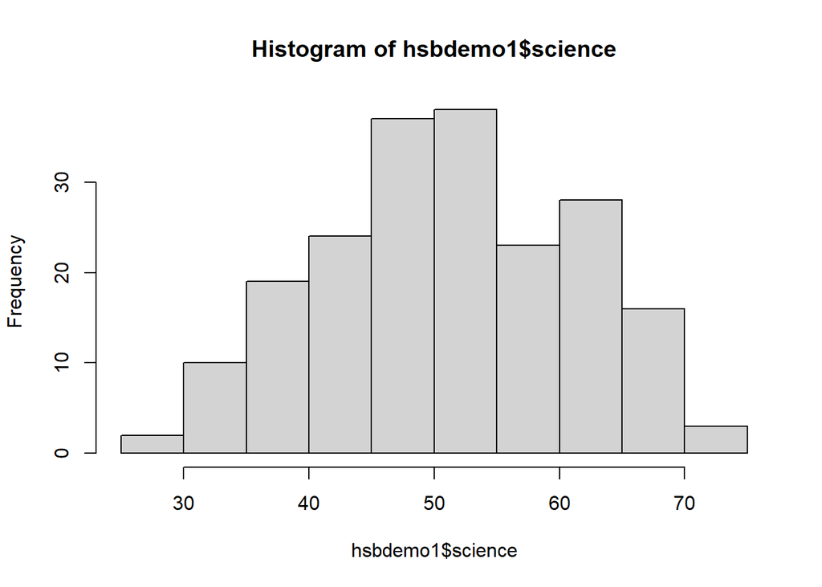

```r
hist(hsbdemo1$science)
```

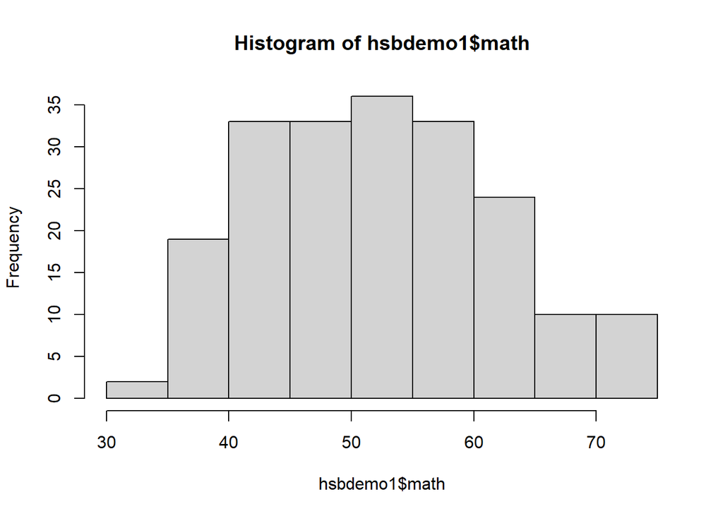

```r
hist(hsbdemo1$math)
```

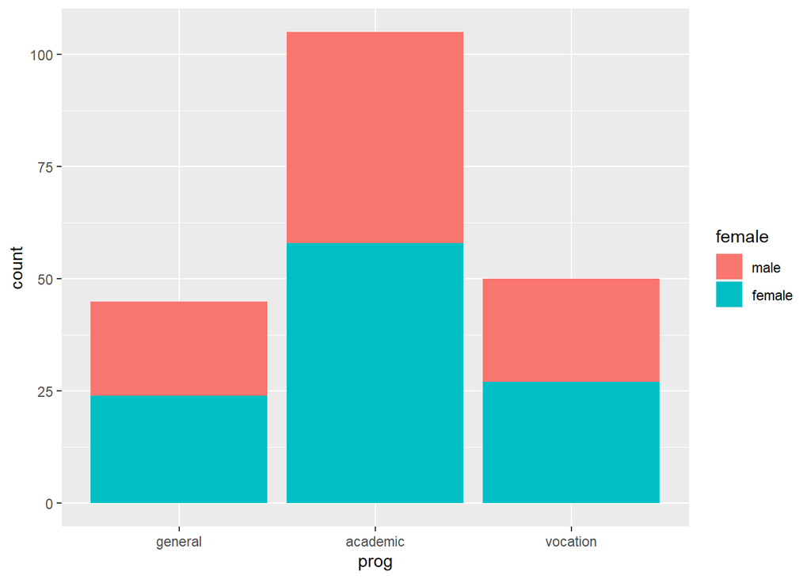

```r
ggplot(hsbdemo1, aes(x = prog, fill = female)) +
  geom_bar()
```

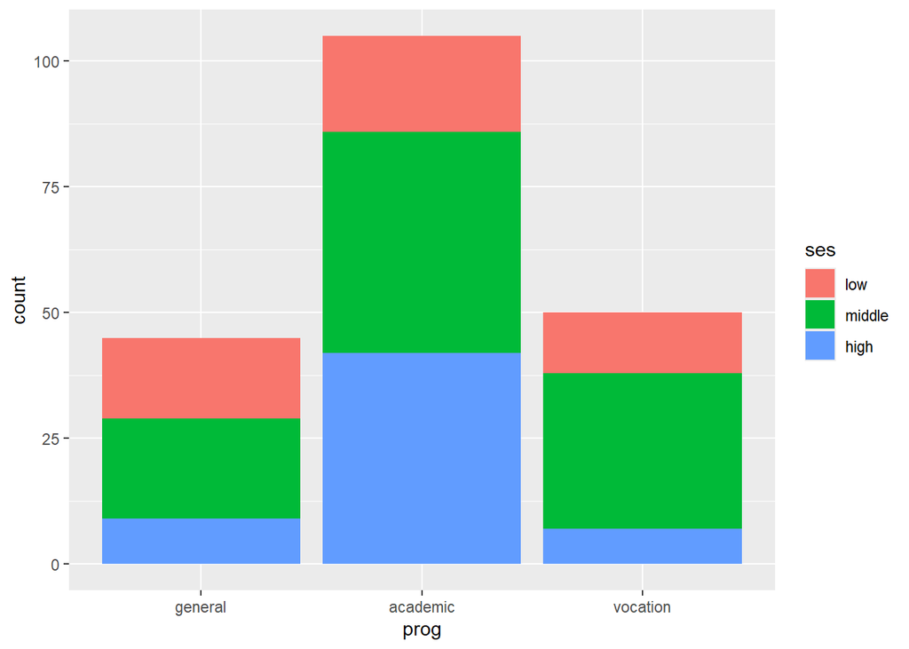

```r
ggplot(hsbdemo1, aes(x = prog, fill = ses)) +
  geom_bar()
```

```r
hsbdemo1 %>% tbl_summary(by = prog,
              statistic = list(all_continuous() ~ "{mean} ({sd})"))
```

| **Characteristic** | **general**, N = 45<sup>1</sup> | **academic**, N = 105<sup>1</sup> | **vocation**, N = 50<sup>1</sup> |
| --- | --- | --- | --- |
| female |  |  |  |
| male | 21 (47%) | 47 (45%) | 23 (46%) |
| female | 24 (53%) | 58 (55%) | 27 (54%) |
| math score | 50 (7) | 57 (9) | 46 (8) |
| science score | 52 (10) | 54 (9) | 47 (10) |
| ses |  |  |  |
| low | 16 (36%) | 19 (18%) | 12 (24%) |
| middle | 20 (44%) | 44 (42%) | 31 (62%) |
| high | 9 (20%) | 42 (40%) | 7 (14%) |

<sup>1</sup> n (%); Mean (SD)

## Logistic Regression Analysis

### Estimation

determine the level of DV

reference: general program

we want to estimate the model for

1. academic (2) vs general (3)
2. vocation (1) vs general (3)

```r
levels(hsbdemo1$prog)
```

```
[1] "general"  "academic" "vocation"
```

we want to use VGAM package. re-level so the last group is the reference group

```r
hsbdemo1 <-
  hsbdemo1 %>%
  mutate(prog2 = fct_relevel(prog,
                       c("vocation", 'academic', 'general')))
```

re-check level

```r
levels(hsbdemo1$prog2)
```

```
[1] "vocation" "academic" "general"
```

fit model - estimate log odds

```r
mn1 <- vglm(prog2 ~ female + math + science + ses, multinomial, data = hsbdemo1)
summary(mn1)
```

```
Call:
vglm(formula = prog2 ~ female + math + science + ses, family = multinomial,
    data = hsbdemo1)

Coefficients:
               Estimate Std. Error z value Pr(>|z|)
(Intercept):1   3.92672    1.53854   2.552   0.0107 *
(Intercept):2  -2.94800    1.35722  -2.172   0.0298 *
femalefemale:1 -0.05717    0.43943  -0.130   0.8965
femalefemale:2  0.08060    0.39895   0.202   0.8399
math:1         -0.03573    0.03375  -1.058   0.2898
math:2          0.12943    0.03078   4.205 2.62e-05 ***
science:1      -0.05523    0.02781  -1.986   0.0470 *
science:2      -0.06996    0.02667  -2.624   0.0087 **
sesmiddle:1     1.08631    0.51384   2.114   0.0345 *
sesmiddle:2     0.47367    0.47502   0.997   0.3187
seshigh:1       0.56064    0.67995   0.825   0.4096
seshigh:2       1.17388    0.55422   2.118   0.0342 *
---
Signif. codes:  0 '***' 0.001 '**' 0.01 '*' 0.05 '.' 0.1 ' ' 1

Names of linear predictors: log(mu[,1]/mu[,3]), log(mu[,2]/mu[,3])

Residual deviance: 339.0322 on 388 degrees of freedom

Log-likelihood: -169.5161 on 388 degrees of freedom

Number of Fisher scoring iterations: 5

No Hauck-Donner effect found in any of the estimates


Reference group is level  3  of the response
```

estimate log odds and RRR

```r
est_mn1 <-cbind(coef(mn1), exp(coef(mn1)))
est_mn1
```

```
                      [,1]        [,2]
(Intercept):1   3.92671836 50.74019311
(Intercept):2  -2.94799829  0.05244458
femalefemale:1 -0.05717325  0.94443043
femalefemale:2  0.08059959  1.08393680
math:1         -0.03572539  0.96490523
math:2          0.12942787  1.13817701
science:1      -0.05523066  0.94626686
science:2      -0.06996051  0.93243064
sesmiddle:1     1.08631459  2.96333283
sesmiddle:2     0.47366581  1.60587024
seshigh:1       0.56063529  1.75178503
seshigh:2       1.17388019  3.23451885
```

### Inference

```r
ci_mn1 <-cbind(confint(mn1), exp(confint(mn1)))
ci_mn1
```

```
                     2.5 %        97.5 %       2.5 %       97.5 %
(Intercept):1   0.91123719  6.9421995262 2.487398024 1035.0443202
(Intercept):2  -5.60810757 -0.2878890145 0.003668004    0.7498448
femalefemale:1 -0.91843594  0.8040894403 0.399142837    2.2346608
femalefemale:2 -0.70132760  0.8625267908 0.495926474    2.3691395
math:1         -0.10187749  0.0304267152 0.903140186    1.0308943
math:2          0.06909517  0.1897605695 1.071538181    1.2089601
science:1      -0.10973779 -0.0007235258 0.896069063    0.9992767
science:2      -0.12222643 -0.0176945943 0.884947969    0.9824610
sesmiddle:1     0.07919813  2.0934310580 1.082418756    8.1127026
sesmiddle:2    -0.45735875  1.4046903809 0.632953225    4.0742651
seshigh:1      -0.77204998  1.8933205463 0.462064875    6.6413851
seshigh:2       0.08762905  2.2601313232 1.091583122    9.5843477
```

combine estimates and inferences

```r
res_mn1 <- cbind(est_mn1, ci_mn1)
colnames(res_mn1) <- c('b', 'rrr',
                            'lower 95% b','upper 95% b',
                            'lower 95% rrr' , 'upper b95% rrr')
res_mn1
```

```
                         b         rrr lower 95% b   upper 95% b lower 95% rrr
(Intercept):1   3.92671836 50.74019311  0.91123719  6.9421995262   2.487398024
(Intercept):2  -2.94799829  0.05244458 -5.60810757 -0.2878890145   0.003668004
femalefemale:1 -0.05717325  0.94443043 -0.91843594  0.8040894403   0.399142837
femalefemale:2  0.08059959  1.08393680 -0.70132760  0.8625267908   0.495926474
math:1         -0.03572539  0.96490523 -0.10187749  0.0304267152   0.903140186
math:2          0.12942787  1.13817701  0.06909517  0.1897605695   1.071538181
science:1      -0.05523066  0.94626686 -0.10973779 -0.0007235258   0.896069063
science:2      -0.06996051  0.93243064 -0.12222643 -0.0176945943   0.884947969
sesmiddle:1     1.08631459  2.96333283  0.07919813  2.0934310580   1.082418756
sesmiddle:2     0.47366581  1.60587024 -0.45735875  1.4046903809   0.632953225
seshigh:1       0.56063529  1.75178503 -0.77204998  1.8933205463   0.462064875
seshigh:2       1.17388019  3.23451885  0.08762905  2.2601313232   1.091583122
               upper b95% rrr
(Intercept):1    1035.0443202
(Intercept):2       0.7498448
femalefemale:1      2.2346608
femalefemale:2      2.3691395
math:1              1.0308943
math:2              1.2089601
science:1           0.9992767
science:2           0.9824610
sesmiddle:1         8.1127026
sesmiddle:2         4.0742651
seshigh:1           6.6413851
seshigh:2           9.5843477
```

### Prediction

predict log odds for the first 6 observation

first column: vocation vs general, 2nd column academic vs general

```r
head(predict.vgam(mn1, type = 'link'))
```

```
  log(mu[,1]/mu[,3]) log(mu[,2]/mu[,3])
1          0.8031151         0.41028912
2          1.5599883         0.31363176
3          1.4794394         2.10173485
4          0.6036403         0.17927535
5          1.4300217        -0.02567764
6          1.2175637         1.57367615
```

manual calculation

```r
head(hsbdemo1)
```

```
# A tibble: 6 × 6
  prog     female  math science ses    prog2
  <fct>    <fct>  <dbl>   <dbl> <fct>  <fct>
1 vocation female    41      29 low    vocation
2 general  male      41      36 middle general
3 vocation male      44      26 high   vocation
4 vocation male      42      33 low    vocation
5 vocation male      40      39 middle vocation
6 general  female    42      31 high   general
```

for 1st observation (vocational vs general)

```r
3.92671836 + (-0.05717325) + (-0.03572539*41) + (-0.05523066*29) + 0
```

```
[1] 0.803115
```

predict probability for first 6 observation

```r
head(predict.vgam(mn1, type = 'response'))
```

```
   vocation  academic    general
1 0.4710143 0.3180035 0.21098213
2 0.6676953 0.1919962 0.14030851
3 0.3235235 0.6027890 0.07368744
4 0.4543384 0.2972214 0.24844016
5 0.6790983 0.1583910 0.16251075
6 0.3671451 0.5241981 0.10865672
```

for 1st observation

- probability being in general group

```r
1/(1 + exp(0.8031151) + exp(0.41028912))
```

```
[1] 0.2109821
```

- probability being in vocational group

```r
exp(0.8031151)/(1 + exp(0.8031151) + exp(0.41028912))
```

```
[1] 0.4710143
```

- probability being in academic group

```r
exp(0.41028912)/(1 + exp(0.8031151) + exp(0.41028912))
```

```
[1] 0.3180035
```

## using NNET

first group as reference, no need to relevel the original data set

```r
library(nnet)
mn1.nnet <- multinom(prog ~ female + math + science + ses, data = hsbdemo1)
mn1.nnet
```

```
Call:
multinom(formula = prog ~ female + math + science + ses, data = hsbdemo1)

Coefficients:
         (Intercept) femalefemale        math     science sesmiddle   seshigh
academic   -2.947984   0.08060341  0.12942787 -0.06996117  0.473686 1.1739155
vocation    3.926728  -0.05716079 -0.03572574 -0.05523084  1.086329 0.5606418

Residual Deviance: 339.0322
AIC: 363.0322
```

ci 95%

```r
confint(mn1.nnet, level=0.95)
```

```
, , academic

                   2.5 %      97.5 %
(Intercept)  -5.60809384 -0.28787447
femalefemale -0.70132443  0.86253124
math          0.06909515  0.18976058
science      -0.12222716 -0.01769518
sesmiddle    -0.45733878  1.40471072
seshigh       0.08766316  2.26016789

, , vocation

                   2.5 %        97.5 %
(Intercept)   0.91124293  6.9422130782
femalefemale -0.91842443  0.8041028478
math         -0.10187793  0.0304264564
science      -0.10973805 -0.0007236258
sesmiddle     0.07921266  2.0934459302
seshigh      -0.77204769  1.8933312974
```

## Result Presentation

```r
library(knitr)
library(kableExtra)
```

```r
kable(res_mn1, digits = 3) %>%
  kable_styling(bootstrap_options =
                  c("striped", "hover", "condensed", "responsive"))
```

|  | b | rrr | lower 95% b | upper 95% b | lower 95% rrr | upper b95% rrr |
| --- | --- | --- | --- | --- | --- | --- |
| (Intercept):1 | 3.927 | 50.740 | 0.911 | 6.942 | 2.487 | 1035.044 |
| (Intercept):2 | -2.948 | 0.052 | -5.608 | -0.288 | 0.004 | 0.750 |
| femalefemale:1 | -0.057 | 0.944 | -0.918 | 0.804 | 0.399 | 2.235 |
| femalefemale:2 | 0.081 | 1.084 | -0.701 | 0.863 | 0.496 | 2.369 |
| math:1 | -0.036 | 0.965 | -0.102 | 0.030 | 0.903 | 1.031 |
| math:2 | 0.129 | 1.138 | 0.069 | 0.190 | 1.072 | 1.209 |
| science:1 | -0.055 | 0.946 | -0.110 | -0.001 | 0.896 | 0.999 |
| science:2 | -0.070 | 0.932 | -0.122 | -0.018 | 0.885 | 0.982 |
| sesmiddle:1 | 1.086 | 2.963 | 0.079 | 2.093 | 1.082 | 8.113 |
| sesmiddle:2 | 0.474 | 1.606 | -0.457 | 1.405 | 0.633 | 4.074 |
| seshigh:1 | 0.561 | 1.752 | -0.772 | 1.893 | 0.462 | 6.641 |
| seshigh:2 | 1.174 | 3.235 | 0.088 | 2.260 | 1.092 | 9.584 |

interpretation

compared to male, female have lower estimated odds (by the factor of 0.9) to enrolled to vocational program compared to general program, when adjusted for math & science score, and SES.

however, being female has 1.084 higher estimated odds compared to male to enroll to academic program compared to general program, when adjusted for math & science score, and SES.

for every 1 unit increase in math score, the estimated odds of enrolling to academic program compared to general program increase by 1.138, when adjusted for gender, science score, and SES.

for every 1 unit increase in math score, the estimated odds of enrolling in vocational program over general program decrease when adjusted for gender, science score, and SES.

## simple model

```r
mn.gen <- vglm(prog2 ~ female, multinomial, data = hsbdemo1)
summary(mn.gen)
```

```
Call:
vglm(formula = prog2 ~ female, family = multinomial, data = hsbdemo1)

Coefficients:
               Estimate Std. Error z value Pr(>|z|)
(Intercept):1   0.09097    0.30182   0.301  0.76310
(Intercept):2   0.80563    0.26248   3.069  0.00215 **
femalefemale:1  0.02681    0.41207   0.065  0.94812
femalefemale:2  0.07676    0.35750   0.215  0.82998
---
Signif. codes:  0 '***' 0.001 '**' 0.01 '*' 0.05 '.' 0.1 ' ' 1

Names of linear predictors: log(mu[,1]/mu[,3]), log(mu[,2]/mu[,3])

Residual deviance: 408.1406 on 396 degrees of freedom

Log-likelihood: -204.0703 on 396 degrees of freedom

Number of Fisher scoring iterations: 4

No Hauck-Donner effect found in any of the estimates


Reference group is level  3  of the response
```

```r
est_mn.gen <-cbind(coef(mn.gen), exp(coef(mn.gen)))
ci_mn.gen <-cbind(confint(mn.gen), exp(confint(mn.gen)))
res_mn.gen <- cbind(est_mn.gen, ci_mn.gen)
colnames(res_mn.gen) <- c('b', 'rrr',
                            'lower 95% b','upper 95% b',
                            'lower 95% rrr' , 'upper b95% rrr')
res_mn.gen
```

```
                        b      rrr lower 95% b upper 95% b lower 95% rrr
(Intercept):1  0.09097178 1.095238  -0.5005910   0.6825346     0.6061723
(Intercept):2  0.80562516 2.238095   0.2911742   1.3200761     1.3379977
femalefemale:1 0.02681126 1.027174  -0.7808295   0.8344520     0.4580259
femalefemale:2 0.07676402 1.079787  -0.6239161   0.7774441     0.5358419
               upper b95% rrr
(Intercept):1        1.978887
(Intercept):2        3.743706
femalefemale:1       2.303551
femalefemale:2       2.175904
```

```r
kable(res_mn.gen, digits = 3) %>%
  kable_styling(bootstrap_options =
                  c("striped", "hover", "condensed", "responsive"))
```

|  | b | rrr | lower 95% b | upper 95% b | lower 95% rrr | upper b95% rrr |
| --- | --- | --- | --- | --- | --- | --- |
| (Intercept):1 | 0.091 | 1.095 | -0.501 | 0.683 | 0.606 | 1.979 |
| (Intercept):2 | 0.806 | 2.238 | 0.291 | 1.320 | 1.338 | 3.744 |
| femalefemale:1 | 0.027 | 1.027 | -0.781 | 0.834 | 0.458 | 2.304 |
| femalefemale:2 | 0.077 | 1.080 | -0.624 | 0.777 | 0.536 | 2.176 |

```r
pp<- cbind(hsbdemo1, predict(mn1, newdata = hsbdemo1, type = "response"))
```

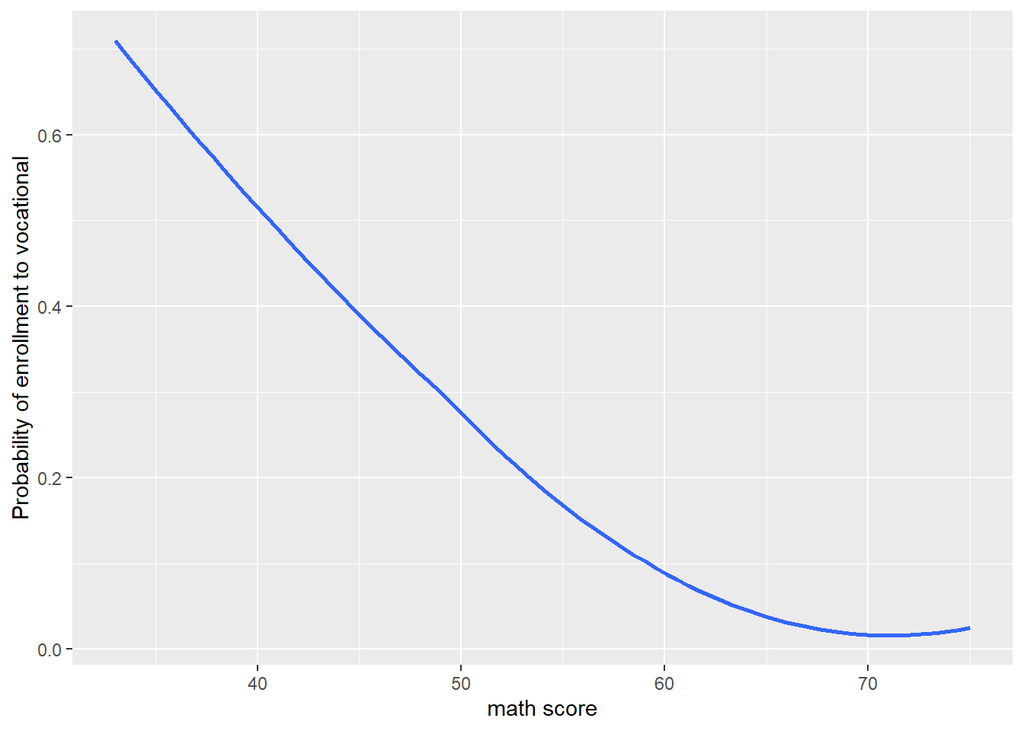

```r
prob_plotmn <- pp %>%
  ggplot(aes(x = math, y = vocation)) +
  geom_smooth(method = "loess", se = FALSE) +
  labs(x = "math score", y = "Probability of enrollment to vocational")
prob_plotmn
```

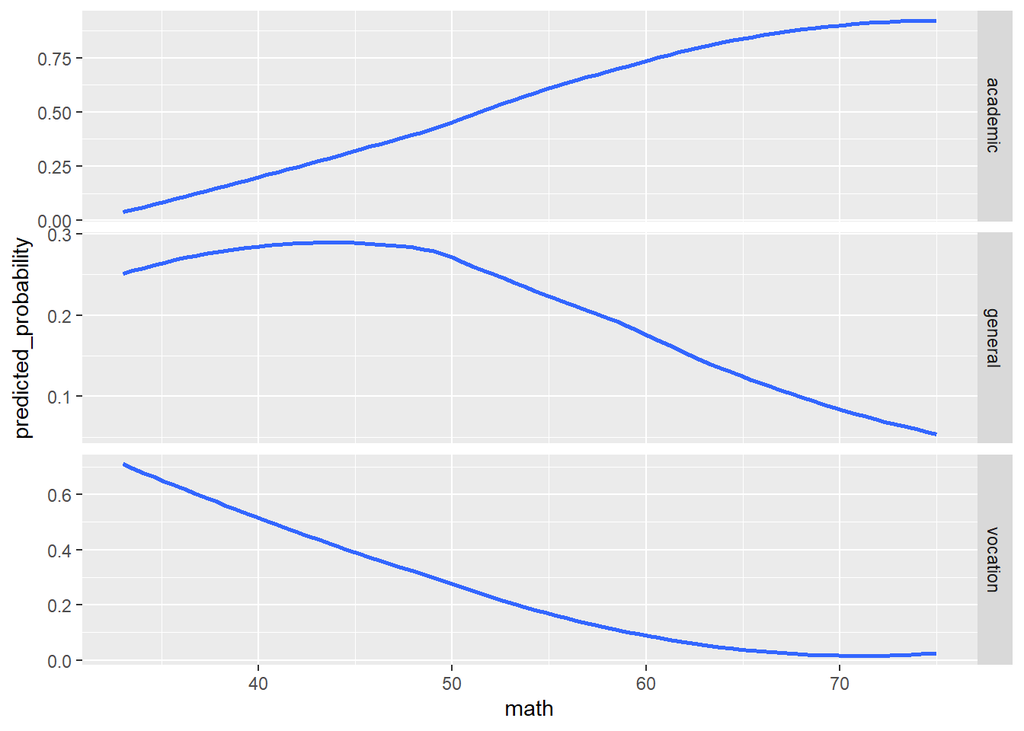

```r
pp_long <- pp %>%
  pivot_longer(cols = c("vocation", "academic", "general"),
               names_to = "prog3",
               values_to = "predicted_probability")

plot_math <-ggplot(pp_long, aes(x = math, y = predicted_probability)) + geom_smooth(method = "loess", se = FALSE) + facet_grid(vars(prog3), scales = "free")
plot_math
```

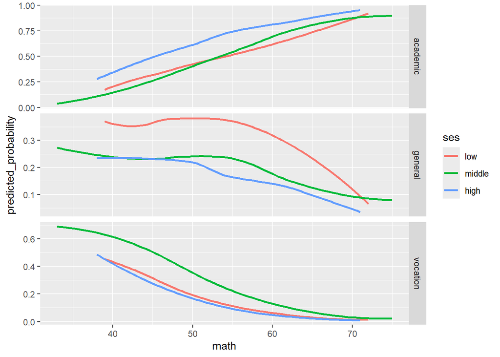

```r
ggplot(pp_long, aes(x = math, y = predicted_probability, color = ses)) +
  geom_smooth(method = "loess", se = FALSE) +
  facet_grid(vars(prog3), scales = "free")
```

## model comparison

likelihood ratio test

log likelihood

model 1: -204.0703

model 2: -169.5161

```r
-2 * ((-204.0703) - (-169.5161))
```

```
[1] 69.1084
```

```r
llmn.gen <-logLik(mn.gen)
llmn1 <-logLik(mn1)
LRT <- (-2 * (llmn.gen - llmn1))
```

df

```r
df = df.residual(mn.gen) - df.residual(mn1)
df
```

```
[1] 8
```

chisquare

```r
pchisq(LRT, df, lower.tail = FALSE)
```

```
[1] 7.394069e-12
```

```r
lrtest(mn.gen,mn1)
```

```
Likelihood ratio test

Model 1: prog2 ~ female
Model 2: prog2 ~ female + math + science + ses
  #Df  LogLik Df  Chisq Pr(>Chisq)
1 396 -204.07
2 388 -169.52 -8 69.108  7.394e-12 ***
---
Signif. codes:  0 '***' 0.001 '**' 0.01 '*' 0.05 '.' 0.1 ' ' 1
```